# Project 2

STATS 220 Semester One 2024

Akira Kalam

```css
@import url('https://fonts.googleapis.com/css2?family=Playfair+Display');
body {
  background-color: #D8BFD8;
  color: #51414F;
  font-family: 'Playfair Display', serif;
}
```

## Introduction

In my report on human behaviour regarding sleep patterns, I designed a form adhering to the four guidelines for design forms. One guideline I adhered to was Guideline 3: Consider your respondents. All questions were gender-neutral and phrased in a non-confrontational tone to ensure inclusivity. Additionally, anonymity was maintained, especially in optional questions regarding respondents’ university stage year. This approach prioritised the comfort and privacy of participants, fostering an environment that was facilitative to honest responses. By implementing these considerations, I aimed to gather reliable data while respecting the diverse backgrounds and preferences of the respondents.

The data obtained from the form provides a valuable source for analysing changes in sleep behaviour over time. For example, Question 4 seeks information on the average nightly sleep duration, which provides a numerical measure for tracking changes in sleep patterns over time. Furthermore, Question 7 looks into the factors influencing sleep, providing an understanding of potential external influences that could affect sleep quality and quantity. Correlating responses to these questions allows for a sense of patterns and trends and the factors contributing to changes in sleep behaviour from week to week.

In summary, I made the form user-friendly, respectful, and efficient to collect reliable data on sleep patterns by considering the responders’ needs and preferences. Following Guideline 3 improves the data’s validity and dependability and simplifies the respondents’ experience.

This is the link to my Google form: https://forms.gle/KAk1QbuYjssmN8nM6

## Analytics

I noticed that students without reported sleep troubles tend to sleep more hours per night than those who report sleep issues, indicating a potential correlation between reported sleep troubles and shorter sleep duration.

I observed that most students answered stress as affecting their ability to sleep, suggesting that stress is a prevalent issue impacting students’ sleep quality.

### Renaming the variables in the data frame

```r
# URL for the Google sheet published as a CSV
csv_file <- "https://docs.google.com/spreadsheets/d/e/2PACX-1vQj6sXpQHrvwVV-1GanmqqS2Op7S685mmhHeSmD73mTGey34-oMx28YbrVmX4piMYXSN9cZS3XEtrbX/pub?output=csv"

# Using the read_csv() function to read the data into a data frame called learning_data
# Renaming the variables in the data frame
learning_data <- read_csv(csv_file) %>%
  rename(time_stamp = 1,
         university_year = 2,
         sleep_time = 3,
         wake_time = 4,
         sleep_hours = 5,
         sleep_trouble = 6,
         sleep_rating = 7,
         sleep_factors = 8,
         work_commitments = 9,
         work_hours = 10,)

glimpse(learning_data)
```

```
## Rows: 21
## Columns: 10
## $ time_stamp       <chr> "30/03/2024 00:11:05", "30/03/2024 00:12:30", "30/03/…
## $ university_year  <chr> "1st Year", "4th Year", "2nd Year", "3rd Year", "3rd …
## $ sleep_time       <chr> "3:00 AM +", "3:00 AM +", "10:00 PM", "3:00 AM +", "2…
## $ wake_time        <chr> "12:00 PM +", "10:00 AM", "6:00 AM", "11:00 AM", "8:0…
## $ sleep_hours      <dbl> 5.0, 7.0, 8.0, 4.0, 6.0, 4.5, 6.0, 7.0, 6.5, 6.0, 8.0…
## $ sleep_trouble    <chr> "Yes", "Yes", "Yes", "Yes", "No", "Yes", "No", "No", …
## $ sleep_rating     <chr> "Poor", "Poor", "Fair", "Poor", "Fair", "Poor", "Fair…
## $ sleep_factors    <chr> "Stress, Screentime (e.g. phone, TV, etc.)", "Stress,…
## $ work_commitments <chr> "Yes", "Yes", "Yes", "Yes", "Yes", "No", "Yes", "Yes"…
## $ work_hours       <dbl> 40, 8, 16, 17, 25, 0, 16, 20, 27, 8, 14, 8, 20, 25, 2…
```

### Vertical bar chart displaying the relationship between the sleep ratings of participants with how many hours per week they work outside of university

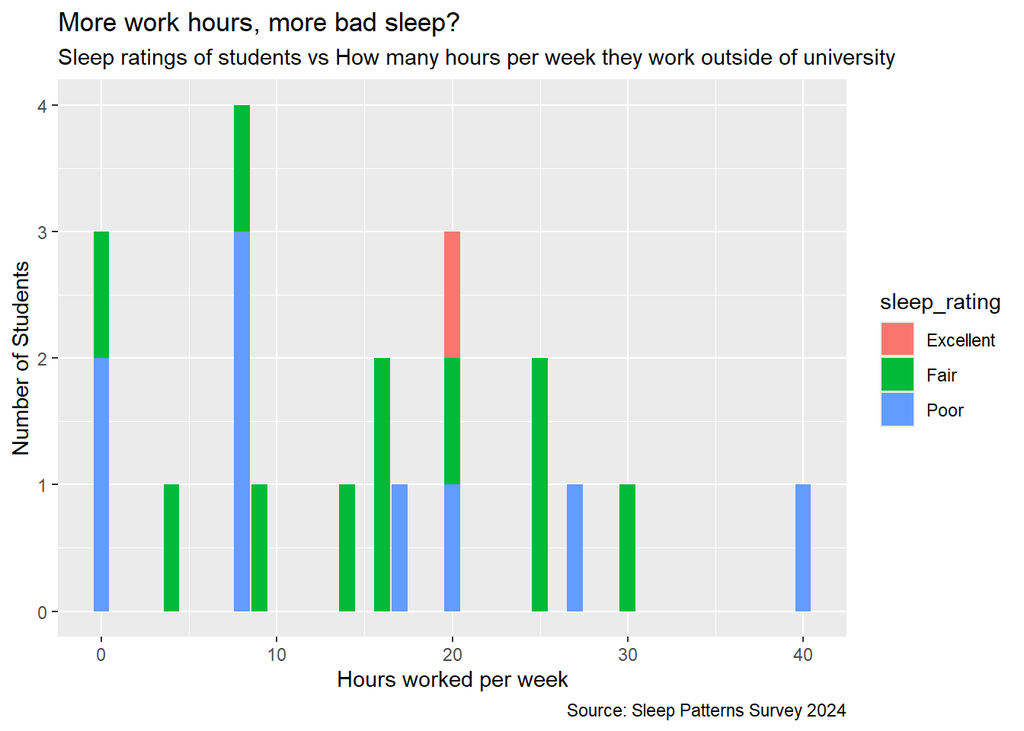

```r
# Vertical bar chart displaying the relationship between the sleep ratings of participants with how many hours per week they work outside of university
ggplot(data = learning_data) +
  geom_bar(aes(x = work_hours, fill = sleep_rating)) +
labs(title = "More work hours, more bad sleep?",
     subtitle = "Sleep ratings of students vs How many hours per week they work outside of university",
     caption = "Source: Sleep Patterns Survey 2024",
     x = "Hours worked per week",
     y = "Number of Students" )
```

### Vertical bar chart displaying the relationship between if participants have troubles falling asleep and how many hours of sleep they get per night

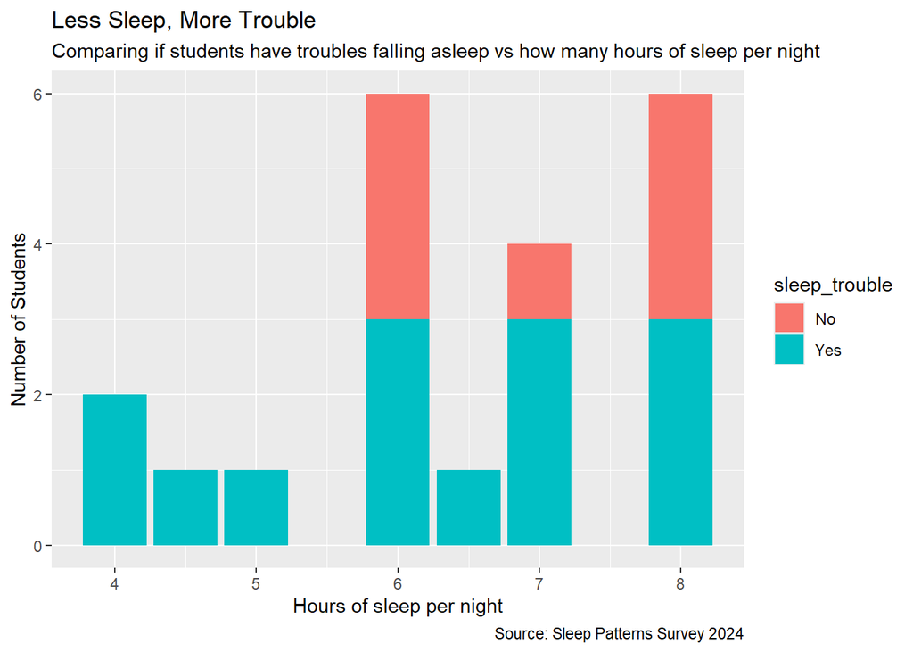

```r
# Vertical bar chart displaying the relationship between if participants have troubles falling asleep and how many hours of sleep they get per night
ggplot(data = learning_data) +
  geom_bar(aes(x = sleep_hours, fill = sleep_trouble)) +
labs(title = "Less Sleep, More Trouble",
     subtitle = "Comparing if students have troubles falling asleep vs how many hours of sleep per night",
     caption = "Source: Sleep Patterns Survey 2024",
     x = "Hours of sleep per night",
     y = "Number of Students")
```

### What was the minimum hours of sleep that a university student got per night?

```r
# What was the minimum hours of sleep that a university student got per night?
paste("The minimum hours of sleep a university student got per night is", learning_data$sleep_hours %>% min(), "hours.")
```

```
## [1] "The minimum hours of sleep a university student got per night is 4 hours."
```

### What was the maximum hours that a university students works outside of university?

```r
# What was the maximum hours that a university students works outside of university?
paste("The maximum hours a university student works outside of university is", learning_data$work_hours %>% max(), "hours.")
```

```
## [1] "The maximum hours a university student works outside of university is 40 hours."
```

## Creativity

In this project, I showcased creativity by skillfully incorporating concepts from Module 1 to elevate the presentation of my report. Drawing upon my ability in HTML and CSS, I applied customised styling to the HTML output of my analysis, ingraining it with visual appeal and enhancing reader engagement. Moreover, I opted for a structured and visually appealing layout for the analytics section. I enhanced the report’s readability by segmenting the R code into distinct chunks accompanied by descriptive subheaders. I ensured that the statistical insights were conveyed in a clear and accessible manner. This thoughtful approach not only demonstrated my technical skills but also elevated the overall quality of the project presentation.

## Learning Reflection

One important idea I learned from Module 2 is the significance of renaming variables when reading data from sources like Google Forms or CSV files. This practice enhances data exploration and analysis by making variables shorter and more identifiable. Renaming variables facilitates clarity and efficiency in understanding the dataset’s structure and features, thus streamlining the following analytical processes. Learning how to create box plots using the ggplot2 package was particularly helpful. It provided insights into the structure of box plots and how to customise them with colours, making variables visually distinctive and aiding in data interpretation. This newfound knowledge sparked my curiosity to delve deeper into data visualisation techniques and explore advanced features of ggplot2 for creating impactful visualisations.